# mBT_vs_VSN

Becske Melinda

2024-08-17

## 1. MI

### Adatrendezés

```r
MI <- read_excel("MI.xlsx", sheet = 1)[,c(1:31)]
MI_av <- read_excel("MI.xlsx", sheet = 1)[,c(1,32:37)]

MI_long <- MI %>%
  pivot_longer(
    cols = c(2:31),
    names_to = "variable",
    values_to = "accuracy"
  )

MI_long <-MI_long %>%
  separate_wider_delim(variable, delim = "_", names = c("ML", "equipment", "run"))

MI_av_long <- MI_av %>%
  pivot_longer(
    cols = c(2:7),
    names_to = "variable",
    values_to = "accuracy"
  )

MI_av_long <-MI_av_long %>%
  separate_wider_delim(variable, delim = "_", names = c("ML", "equipment"))

MI_long$ML <- as.factor(MI_long$ML)
MI_long$equipment <- as.factor(MI_long$equipment)
MI_long$run <- as.factor(MI_long$run)
```

### Adatok

```r
DT::datatable(MI_long)
```

|  | ID | ML | equipment | run | accuracy |
| --- | --- | --- | --- | --- | --- |
| 1 | RM0 | SVM | VSN | 1 | 0.912280702 |
| 2 | RM0 | SVM | VSN | 2 | 0.947368421 |
| 3 | RM0 | SVM | VSN | 3 | 0.859649123 |
| 4 | RM0 | SVM | VSN | 4 | 0.877192982 |
| 5 | RM0 | SVM | VSN | 5 | 0.877192982 |
| 6 | RM0 | SVM | mBT | 1 | 0.846153846 |
| 7 | RM0 | SVM | mBT | 2 | 0.846153846 |
| 8 | RM0 | SVM | mBT | 3 | 0.826923077 |
| 9 | RM0 | SVM | mBT | 4 | 0.75 |
| 10 | RM0 | SVM | mBT | 5 | 0.730769231 |

[output cut: 470 more lines]

```r
# átlagolt
DT::datatable(MI_av_long)
```

|  | ID | ML | equipment | accuracy |
| --- | --- | --- | --- | --- |
| 1 | RM0 | SVM | VSN | 0.894736842 |
| 2 | RM0 | SVM | mBT | 0.8 |
| 3 | RM0 | RF | VSN | 0.870175439 |
| 4 | RM0 | RF | mBT | 0.815384615 |
| 5 | RM0 | CNN | VSN | 0.926315796 |
| 6 | RM0 | CNN | mBT | 0.75 |
| 7 | BR | SVM | VSN | 0.728813559 |
| 8 | BR | SVM | mBT | 0.667857143 |
| 9 | BR | RF | VSN | 0.725423729 |
| 10 | BR | RF | mBT | 0.539285714 |

[output cut: 86 more lines]

### Leíró statisztikák

```r
leiro <- MI_av_long %>%
  group_by(ML,equipment)  %>%
  summarise(átlag= round(mean(accuracy),3), szórás=round(sd(accuracy),3))

knitr::kable(leiro)
```

| ML | equipment | átlag | szórás |
| --- | --- | --- | --- |
| CNN | VSN | 0.851 | 0.077 |
| CNN | mBT | 0.850 | 0.094 |
| RF | VSN | 0.739 | 0.114 |
| RF | mBT | 0.780 | 0.091 |
| SVM | VSN | 0.773 | 0.103 |
| SVM | mBT | 0.798 | 0.103 |

### Ábrák

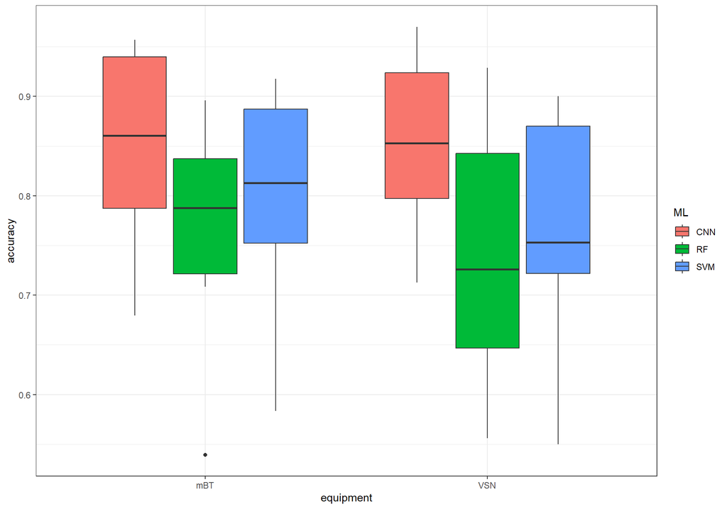

```r
ggplot(MI_av_long, aes(x= equipment, y= accuracy, fill=ML)) +
  geom_boxplot() +
  theme_bw()
```

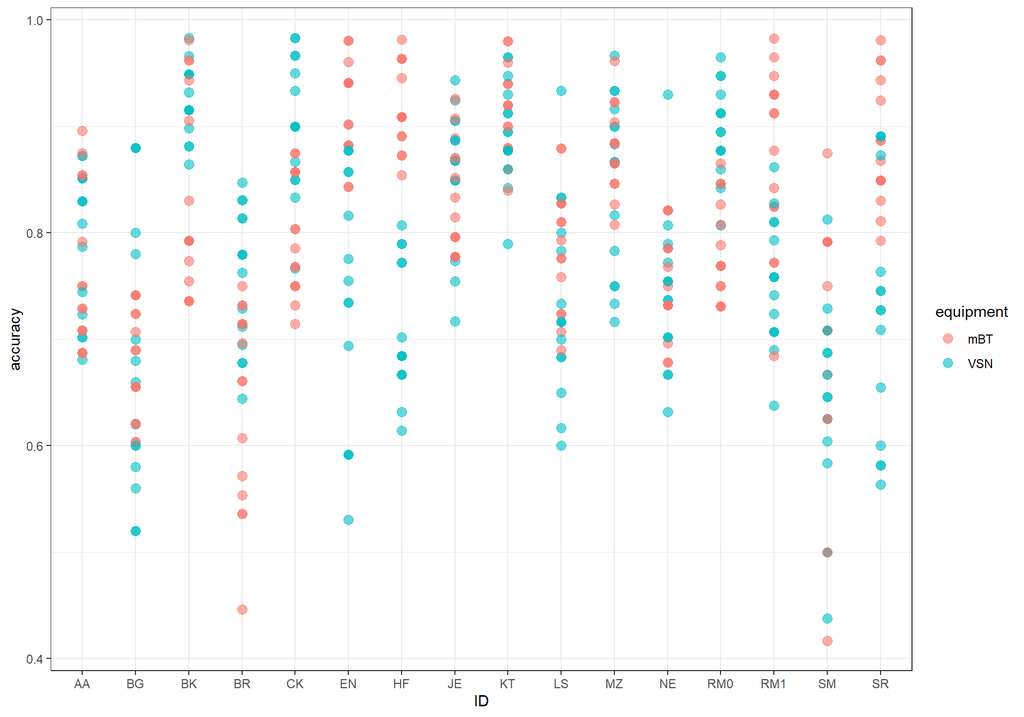

```r
ggplot(MI_long, aes(x=ID, y=accuracy, color=equipment)) +
  geom_point(size=3,alpha=0.6) +
  theme_bw()
```

### Kevert modell -> accuracy ~ ML + equipment (additív + nem változtattam a kovariancia struktúrán)

Ha így illesztem a modellt, akkor mind az ML módszer, mind az eszköz hatása szignifikáns, és a VSN esetében alacsonyabb a klasszifikációs pontosság.

```r
lme.0 <- lme(accuracy ~ ML + equipment,
                random = ~  1|ID,
                data = MI_long)

summary(lme.0)
```

```
## Linear mixed-effects model fit by REML
##   Data: MI_long
##         AIC       BIC   logLik
##   -976.8996 -951.9071 494.4498
##
## Random effects:
##  Formula: ~1 | ID
##         (Intercept)   Residual
## StdDev:  0.06953654 0.07976563
##
## Fixed effects:  accuracy ~ ML + equipment
##                   Value   Std.Error  DF   t-value p-value
## (Intercept)   0.8615700 0.018847531 461  45.71262   0.000
## MLRF         -0.0915366 0.008918069 461 -10.26417   0.000
## MLSVM        -0.0653531 0.008918069 461  -7.32816   0.000
## equipmentVSN -0.0217491 0.007281573 461  -2.98687   0.003
##  Correlation:
##              (Intr) MLRF   MLSVM
## MLRF         -0.237
## MLSVM        -0.237  0.500
## equipmentVSN -0.193  0.000  0.000
##
## Standardized Within-Group Residuals:
##         Min          Q1         Med          Q3         Max
## -3.14285958 -0.66384859  0.07608196  0.72066875  2.03606220
##
## Number of Observations: 480
## Number of Groups: 16
```

```r
anova(lme.0)
```

```
##             numDF denDF   F-value p-value
## (Intercept)     1   461 2020.6483  <.0001
## ML              2   461   55.8917  <.0001
## equipment       1   461    8.9214   0.003
```

### Kevert modell -> accuracy ~ ML + equipment (additív + személyenként eltérő variancia)

Látjuk azonban az ábrán, hogy a szórások személyenként erősen eltérnek. Ha megengedem, hogy személyenként eltérjen a variancia, akkor már az eszköz hatás nem szignifikáns, vagyis nincs szign. különbség a két eszköznél a klaszifikációs pontosságban.

```r
lme.1 <- lme(accuracy ~ ML + equipment,
                random = ~  1|ID,
                weights = varIdent(form = ~1|ID),
                data = MI_long)

summary(lme.1)
```

```
## Linear mixed-effects model fit by REML
##   Data: MI_long
##        AIC       BIC   logLik
##   -1004.34 -916.8665 523.1701
##
## Random effects:
##  Formula: ~1 | ID
##         (Intercept)   Residual
## StdDev:  0.06959304 0.06476357
##
## Variance function:
##  Structure: Different standard deviations per stratum
##  Formula: ~1 | ID
##  Parameter estimates:
##        AA        BG        BK        BR        CK        EN        HF        JE
## 1.0000000 1.2695026 1.0819784 1.3371276 1.1611071 1.6789174 1.7355485 0.7743817
##        KT        LS        MZ        NE       RM0       RM1        SM        SR
## 0.6583122 1.1016457 0.7633902 1.0019906 1.2666468 1.2714718 1.5460264 1.5431736
## Fixed effects:  accuracy ~ ML + equipment
##                   Value   Std.Error  DF   t-value p-value
## (Intercept)   0.8479129 0.018596459 461  45.59540  0.0000
## MLRF         -0.0806239 0.007725926 461 -10.43550  0.0000
## MLSVM        -0.0584169 0.007725926 461  -7.56115  0.0000
## equipmentVSN -0.0053344 0.006308192 461  -0.84563  0.3982
##  Correlation:
##              (Intr) MLRF   MLSVM
## MLRF         -0.208
## MLSVM        -0.208  0.500
## equipmentVSN -0.170  0.000  0.000
##
## Standardized Within-Group Residuals:
##         Min          Q1         Med          Q3         Max
## -2.61842753 -0.70051979  0.09547441  0.76298830  2.11337762
##
## Number of Observations: 480
## Number of Groups: 16
```

```r
anova(lme.1)
```

```
##             numDF denDF   F-value p-value
## (Intercept)     1   461 2019.8512  <.0001
## ML              2   461   58.1109  <.0001
## equipment       1   461    0.7151  0.3982
```

### Kevert modell -> accuracy ~ ML * equipment (interakcióval + személyenként eltérő variancia)

Az előző modellt interakcióval együtt is illesztettem.

```r
lme.int <- lme(accuracy ~ ML * equipment,
             random = ~  1|ID,
             weights = varIdent(form = ~1|ID),
             data = MI_long)

summary(lme.int)
```

```
## Linear mixed-effects model fit by REML
##   Data: MI_long
##         AIC       BIC  logLik
##   -992.6501 -896.9423 519.325
##
## Random effects:
##  Formula: ~1 | ID
##         (Intercept)   Residual
## StdDev:  0.06960624 0.07082001
##
## Variance function:
##  Structure: Different standard deviations per stratum
##  Formula: ~1 | ID
##  Parameter estimates:
##        AA        BG        BK        BR        CK        EN        HF        JE
## 1.0000000 1.0658489 1.0734800 1.2637342 1.0449090 1.4815669 1.5653688 0.7144179
##        KT        LS        MZ        NE       RM0       RM1        SM        SR
## 0.6146918 1.0088923 0.6386836 0.8905239 1.1422792 1.1789833 1.4225292 1.3619944
## Fixed effects:  accuracy ~ ML * equipment
##                         Value  Std.Error  DF  t-value p-value
## (Intercept)         0.8384758 0.01911011 459 43.87604  0.0000
## MLRF               -0.0606592 0.01087174 459 -5.57953  0.0000
## MLSVM              -0.0465438 0.01087174 459 -4.28118  0.0000
## equipmentVSN        0.0138485 0.01087174 459  1.27381  0.2034
## MLRF:equipmentVSN  -0.0420850 0.01537496 459 -2.73724  0.0064
## MLSVM:equipmentVSN -0.0226666 0.01537496 459 -1.47426  0.1411
##  Correlation:
##                    (Intr) MLRF   MLSVM  eqpVSN MLRF:V
## MLRF               -0.284
## MLSVM              -0.284  0.500
## equipmentVSN       -0.284  0.500  0.500
## MLRF:equipmentVSN   0.201 -0.707 -0.354 -0.707
## MLSVM:equipmentVSN  0.201 -0.354 -0.707 -0.707  0.500
##
## Standardized Within-Group Residuals:
##         Min          Q1         Med          Q3         Max
## -2.65494458 -0.69953351  0.06166769  0.73082534  2.02088208
##
## Number of Observations: 480
## Number of Groups: 16
```

```r
anova(lme.int)
```

```
##              numDF denDF   F-value p-value
## (Intercept)      1   459 2019.9478  <.0001
## ML               2   459   59.7463  <.0001
## equipment        1   459    1.5187  0.2184
## ML:equipment     2   459    3.7537  0.0242
```

```r
# plot(lme.int)
#
# qqnorm(residuals(lme.int))
# qqline(residuals(lme.int))
```

### Jobb az interakciós modell, mint az additív?

Újrafuttattam a két modellt Maximum Likelihood módszerrel (különben REML módszet használ, és elvileg akkor nem lehet ezeket a modelleket összehasonlítani). Ez alapján nem szignifikáns a modellek közötti különbség (p = 0.0585), maradhetunk a sima additívnál.

```r
lme.12 <- lme(accuracy ~ ML + equipment, method = "ML",
                random = ~  1|ID,
                weights = varIdent(form = ~1|ID),
                data = MI_long)

summary(lme.12)
```

```
## Linear mixed-effects model fit by maximum likelihood
##   Data: MI_long
##         AIC       BIC   logLik
##   -1034.967 -947.3175 538.4835
##
## Random effects:
##  Formula: ~1 | ID
##         (Intercept)   Residual
## StdDev:  0.06729484 0.06451532
##
## Variance function:
##  Structure: Different standard deviations per stratum
##  Formula: ~1 | ID
##  Parameter estimates:
##        AA        BG        BK        BR        CK        EN        HF        JE
## 1.0000000 1.2718392 1.0826540 1.3395641 1.1620885 1.6833826 1.7400530 0.7724157
##        KT        LS        MZ        NE       RM0       RM1        SM        SR
## 0.6550783 1.1025700 0.7616444 1.0019164 1.2680470 1.2736170 1.5503947 1.5469893
## Fixed effects:  accuracy ~ ML + equipment
##                   Value   Std.Error  DF   t-value p-value
## (Intercept)   0.8478763 0.018126270 461  46.77611  0.0000
## MLRF         -0.0805370 0.007723122 461 -10.42803  0.0000
## MLSVM        -0.0583482 0.007723122 461  -7.55501  0.0000
## equipmentVSN -0.0052951 0.006305903 461  -0.83971  0.4015
##  Correlation:
##              (Intr) MLRF   MLSVM
## MLRF         -0.213
## MLSVM        -0.213  0.500
## equipmentVSN -0.174  0.000  0.000
##
## Standardized Within-Group Residuals:
##         Min          Q1         Med          Q3         Max
## -2.62739293 -0.70568904  0.09209824  0.76553265  2.12082271
##
## Number of Observations: 480
## Number of Groups: 16
```

```r
anova(lme.12)
```

```
##             numDF denDF   F-value p-value
## (Intercept)     1   461 2136.6357  <.0001
## ML              2   461   58.0254  <.0001
## equipment       1   461    0.7051  0.4015
```

```r
lme.int2 <- lme(accuracy ~ ML * equipment, method = "ML",
             random = ~  1|ID,
             weights = varIdent(form = ~1|ID),
             data = MI_long)

summary(lme.int2)
```

```
## Linear mixed-effects model fit by maximum likelihood
##   Data: MI_long
##         AIC       BIC   logLik
##   -1036.644 -940.6467 541.3219
##
## Random effects:
##  Formula: ~1 | ID
##         (Intercept)   Residual
## StdDev:  0.06731398 0.07046974
##
## Variance function:
##  Structure: Different standard deviations per stratum
##  Formula: ~1 | ID
##  Parameter estimates:
##        AA        BG        BK        BR        CK        EN        HF        JE
## 1.0000000 1.0665370 1.0741686 1.2662482 1.0448502 1.4856175 1.5697733 0.7105895
##        KT        LS        MZ        NE       RM0       RM1        SM        SR
## 0.6092100 1.0091266 0.6338108 0.8888452 1.1428866 1.1806483 1.4267892 1.3652552
## Fixed effects:  accuracy ~ ML * equipment
##                         Value  Std.Error  DF  t-value p-value
## (Intercept)         0.8384236 0.01868362 459 44.87479  0.0000
## MLRF               -0.0605097 0.01085639 459 -5.57364  0.0000
## MLSVM              -0.0464866 0.01085639 459 -4.28196  0.0000
## equipmentVSN        0.0138733 0.01085639 459  1.27790  0.2019
## MLRF:equipmentVSN  -0.0421591 0.01535325 459 -2.74594  0.0063
## MLSVM:equipmentVSN -0.0225681 0.01535325 459 -1.46992  0.1423
##  Correlation:
##                    (Intr) MLRF   MLSVM  eqpVSN MLRF:V
## MLRF               -0.291
## MLSVM              -0.291  0.500
## equipmentVSN       -0.291  0.500  0.500
## MLRF:equipmentVSN   0.205 -0.707 -0.354 -0.707
## MLSVM:equipmentVSN  0.205 -0.354 -0.707 -0.707  0.500
##
## Standardized Within-Group Residuals:
##        Min         Q1        Med         Q3        Max
## -2.6670264 -0.7016102  0.0613044  0.7350313  2.0345546
##
## Number of Observations: 480
## Number of Groups: 16
```

```r
anova(lme.int2)
```

```
##              numDF denDF   F-value p-value
## (Intercept)      1   459 2127.7281  <.0001
## ML               2   459   59.7402  <.0001
## equipment        1   459    1.5101  0.2198
## ML:equipment     2   459    3.7764  0.0236
```

```r
anova(lme.12,lme.int2)
```

```
##          Model df       AIC       BIC   logLik   Test  L.Ratio p-value
## lme.12       1 21 -1034.967 -947.3175 538.4835
## lme.int2     2 23 -1036.644 -940.6467 541.3219 1 vs 2 5.676758  0.0585
```

### Kevert modell -> accuracy ~ ML + equipment (additív + eszközönként eltérő variancia)

Megnéztem egy ilyen modellt is…

```r
lme.2 <- lme(accuracy ~ ML + equipment,
                random = ~  1|ID,
                weights = varIdent(form = ~1|equipment),
                data = MI_long)

summary(lme.2)
```

```
## Linear mixed-effects model fit by REML
##   Data: MI_long
##         AIC       BIC   logLik
##   -977.3908 -948.2329 495.6954
##
## Random effects:
##  Formula: ~1 | ID
##         (Intercept)   Residual
## StdDev:  0.07014021 0.08827251
##
## Variance function:
##  Structure: Different standard deviations per stratum
##  Formula: ~1 | equipment
##  Parameter estimates:
##       VSN       mBT
## 1.0000000 0.8110873
## Fixed effects:  accuracy ~ ML + equipment
##                   Value   Std.Error  DF  t-value p-value
## (Intercept)   0.8592112 0.018830913 461 45.62770  0.0000
## MLRF         -0.0872151 0.008792022 461 -9.91980  0.0000
## MLSVM        -0.0625982 0.008792022 461 -7.11989  0.0000
## equipmentVSN -0.0217491 0.007336588 461 -2.96448  0.0032
##  Correlation:
##              (Intr) MLRF   MLSVM
## MLRF         -0.233
## MLSVM        -0.233  0.500
## equipmentVSN -0.155  0.000  0.000
##
## Standardized Within-Group Residuals:
##         Min          Q1         Med          Q3         Max
## -3.56572425 -0.63466967  0.09301253  0.74817878  2.01577370
##
## Number of Observations: 480
## Number of Groups: 16
```

```r
anova(lme.2)
```

```
##             numDF denDF   F-value p-value
## (Intercept)     1   461 2000.9573  <.0001
## ML              2   461   52.3116  <.0001
## equipment       1   461    8.7881  0.0032
```

### De melyik a legjobb modell?

**1. lme.0 vs.lme.1** -> jobb az a modell, ahol megengedtem a személyenként eltérő varianciát, mint ahol nem. **2. lme.2 vs.lme.1** -> jobb az a modell, ahol személyenként eltérő varianciát feltételezek, mint ahol eszközönként eltérőt. **3. lme.12,lme.int2** -> ahogy feljebb is láttuk, nem jobb az interakciós modell az additívnál.

```r
anova(lme.0,lme.1)
```

```
##       Model df        AIC       BIC   logLik   Test  L.Ratio p-value
## lme.0     1  6  -976.8996 -951.9071 494.4498
## lme.1     2 21 -1004.3402 -916.8665 523.1701 1 vs 2 57.44064  <.0001
```

```r
anova(lme.2,lme.1)
```

```
##       Model df        AIC       BIC   logLik   Test  L.Ratio p-value
## lme.2     1  7  -977.3908 -948.2329 495.6954
## lme.1     2 21 -1004.3402 -916.8665 523.1701 1 vs 2 54.94946  <.0001
```

```r
anova(lme.12,lme.int2)
```

```
##          Model df       AIC       BIC   logLik   Test  L.Ratio p-value
## lme.12       1 21 -1034.967 -947.3175 538.4835
## lme.int2     2 23 -1036.644 -940.6467 541.3219 1 vs 2 5.676758  0.0585
```

### Következtetés

Ha így vizsgáljuk az eszközök közötti különbséget, akkor azt látjuk, hogy nincs szignifikáns különbség az eszközök között a klasszifikációs pontosságot illetően.

**Konfidencia intervallumok (CI 95%):**

```r
intervals(lme.1, level = 0.95)
```

```
## Approximate 95% confidence intervals
##
##  Fixed effects:
##                    lower         est.        upper
## (Intercept)   0.81136861  0.847912946  0.884457280
## MLRF         -0.09580631 -0.080623917 -0.065441522
## MLSVM        -0.07359929 -0.058416896 -0.043234501
## equipmentVSN -0.01773076 -0.005334388  0.007061987
##
##  Random Effects:
##   Level: ID
##                      lower       est.     upper
## sd((Intercept)) 0.04791501 0.06959304 0.1010788
##
##  Variance function:
##         lower      est.     upper
## BG  0.8711913 1.2695026 1.8499230
## BK  0.7310910 1.0819784 1.6012743
## BR  0.9230055 1.3371276 1.9370527
## CK  0.8129351 1.1611071 1.6583978
## EN  1.1401696 1.6789174 2.4722318
## HF  1.1772070 1.7355485 2.5587077
## JE  0.5340228 0.7743817 1.1229240
## KT  0.4475189 0.6583122 0.9683948
## LS  0.7479870 1.1016457 1.6225190
## MZ  0.5215895 0.7633902 1.1172858
## NE  0.6773579 1.0019906 1.4822079
## RM0 0.8723929 1.2666468 1.8390728
## RM1 0.8526741 1.2714718 1.8959655
## SM  1.0637574 1.5460264 2.2469388
## SR  1.0352357 1.5431736 2.3003311
##
##  Within-group standard error:
##      lower       est.      upper
## 0.04929680 0.06476357 0.08508300
```

## 2. P300

```r
############### P300 ################

P300 <- read_excel("P300.xlsx", sheet = 1)[,c(1:25)]
P300_av <- read_excel("P300.xlsx", sheet = 1)[,c(1,26:33)]
```

### P300 -> Bland-Altman plots

#### Átlagok

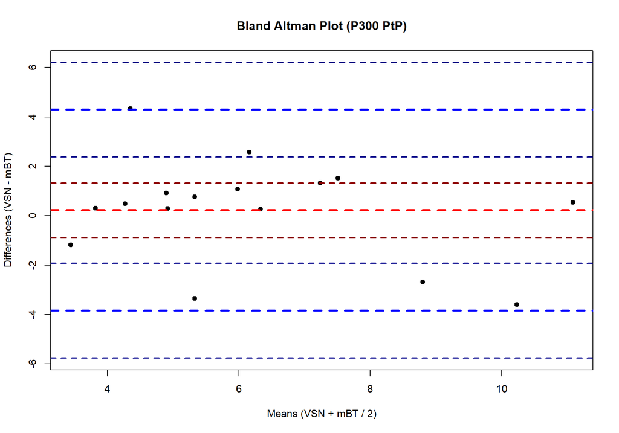

```r
############### P300 -> Bland-Altman plots ################

##### P300 -> átlagok #####

bland.altman.plot(P300_av$VSN_P300_PtP, P300_av$mBT_P300_PtP,
                  conf.int=.95,
                  pch=19,
                  main="Bland Altman Plot (P300 PtP)",
                  xlab="Means (VSN + mBT / 2)",
                  ylab="Differences (VSN - mBT)")
```

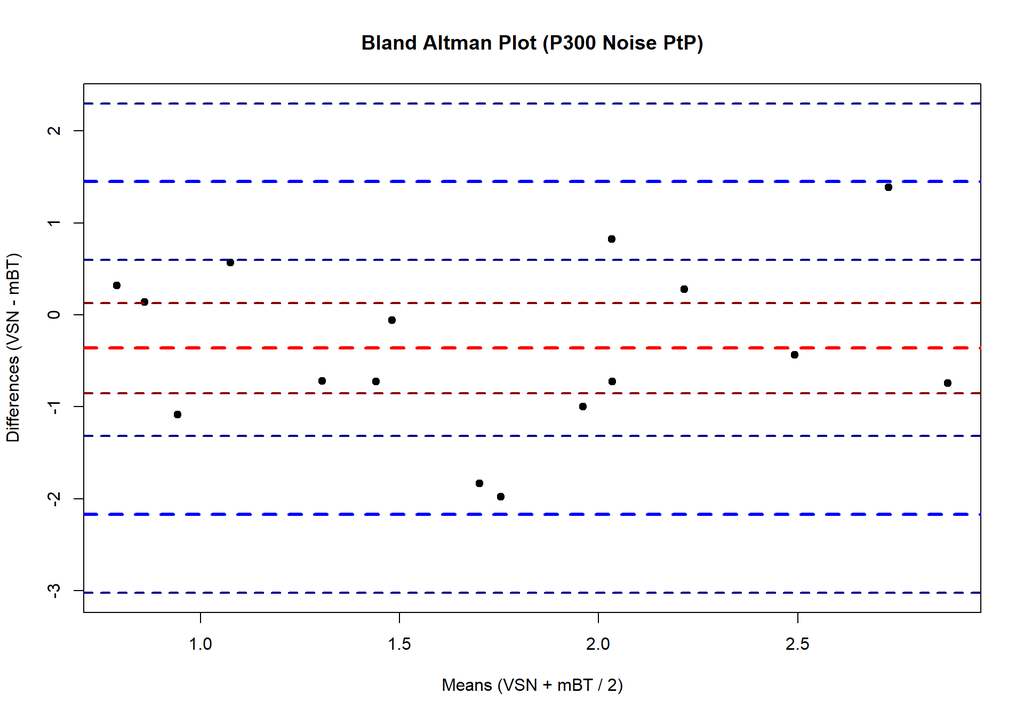

```r
bland.altman.plot(P300_av$VSN_Noise_PtP, P300_av$mBT_Noise_PtP,
                  conf.int=.95,
                  pch=19,
                  main="Bland Altman Plot (P300 Noise PtP)",
                  xlab="Means (VSN + mBT / 2)",
                  ylab="Differences (VSN - mBT)")
```

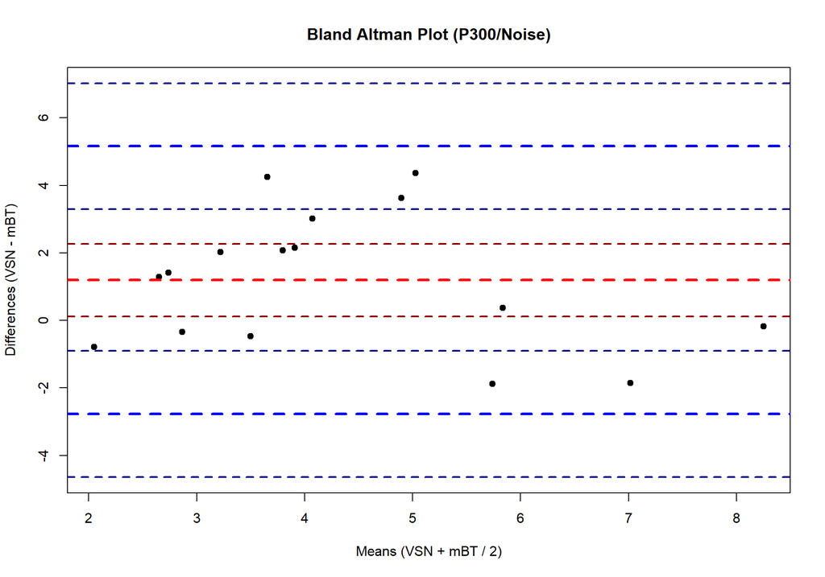

```r
bland.altman.plot(P300_av$VSN_P300_noise, P300_av$mBT_P300_noise,
                  conf.int=.95,
                  pch=19,
                  main="Bland Altman Plot (P300/Noise)",
                  xlab="Means (VSN + mBT / 2)",
                  ylab="Differences (VSN - mBT)")
```

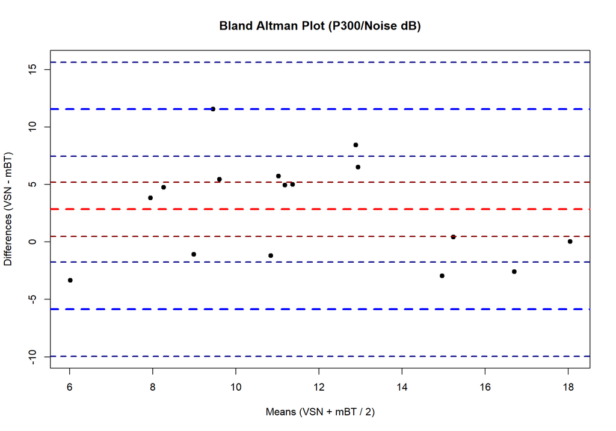

```r
bland.altman.plot(P300_av$VSN_P300_noise_dB, P300_av$mBT_P300_noise_dB,
                  conf.int=.95,
                  pch=19,
                  main="Bland Altman Plot (P300/Noise dB)",
                  xlab="Means (VSN + mBT / 2)",
                  ylab="Differences (VSN - mBT)")
```

#### Csatorák külön-külön

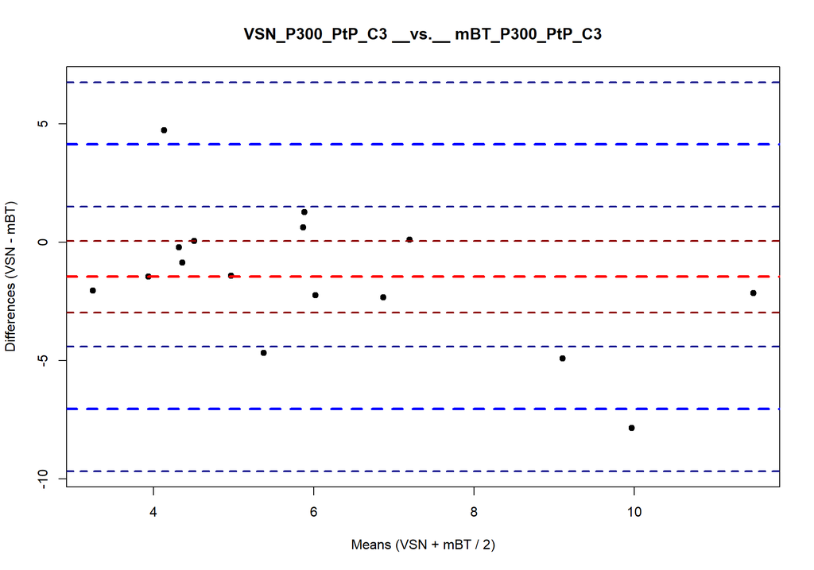

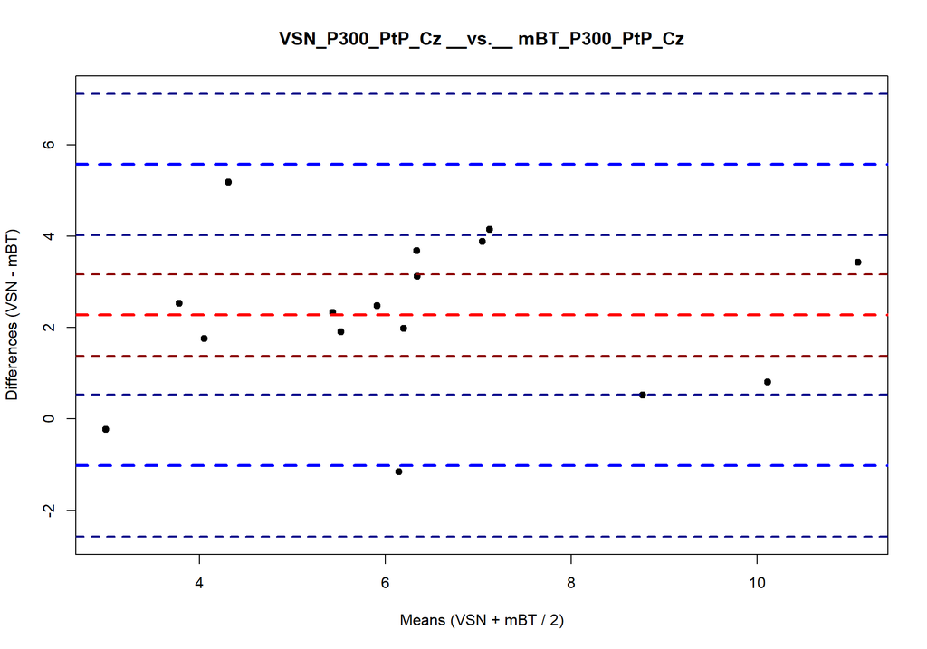

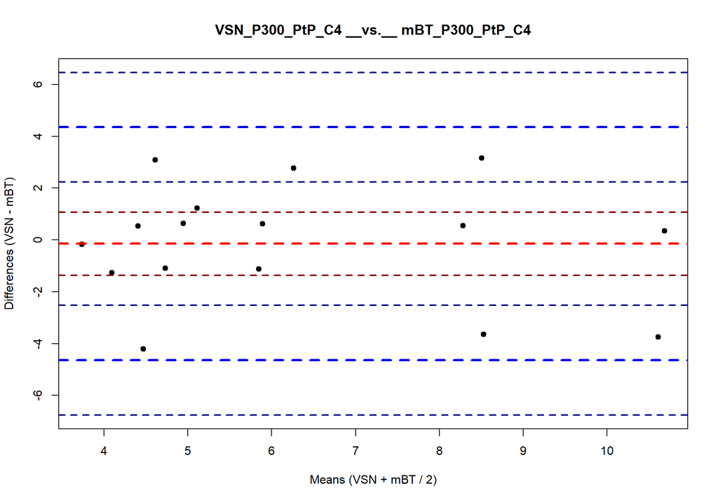

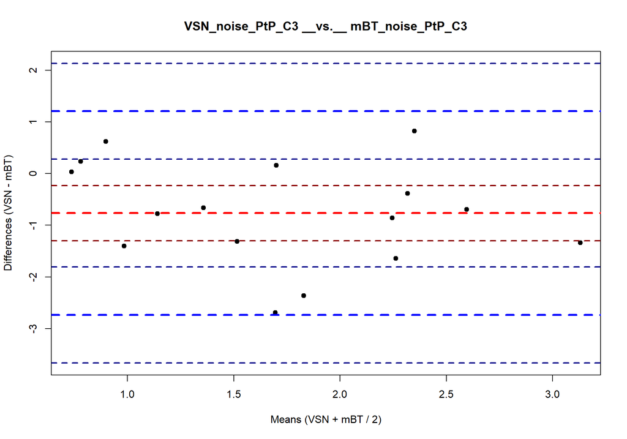

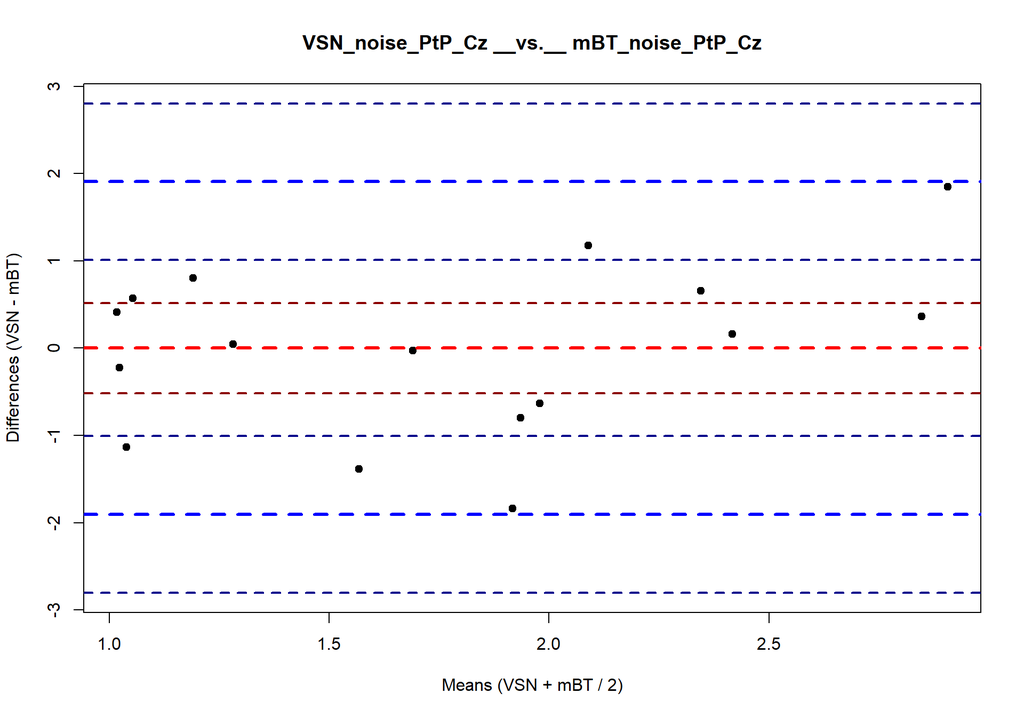

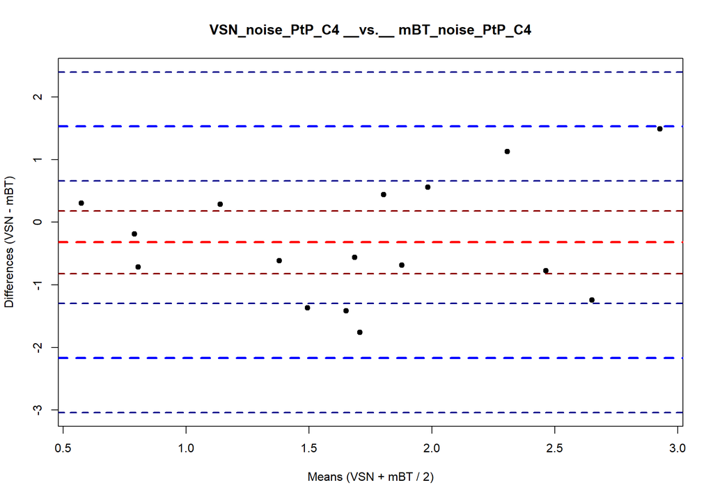

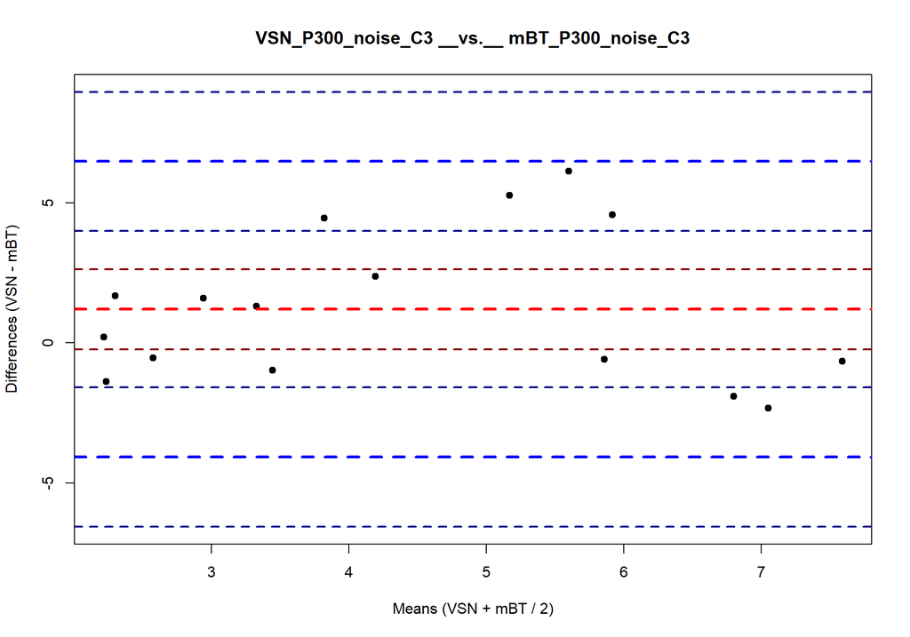

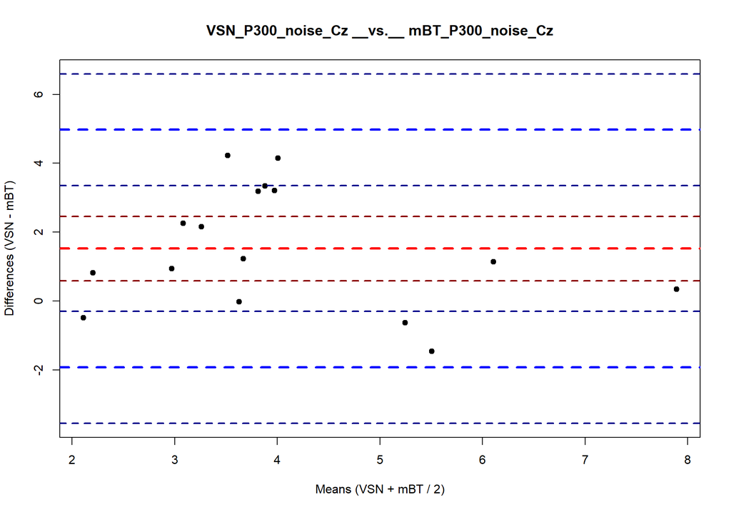

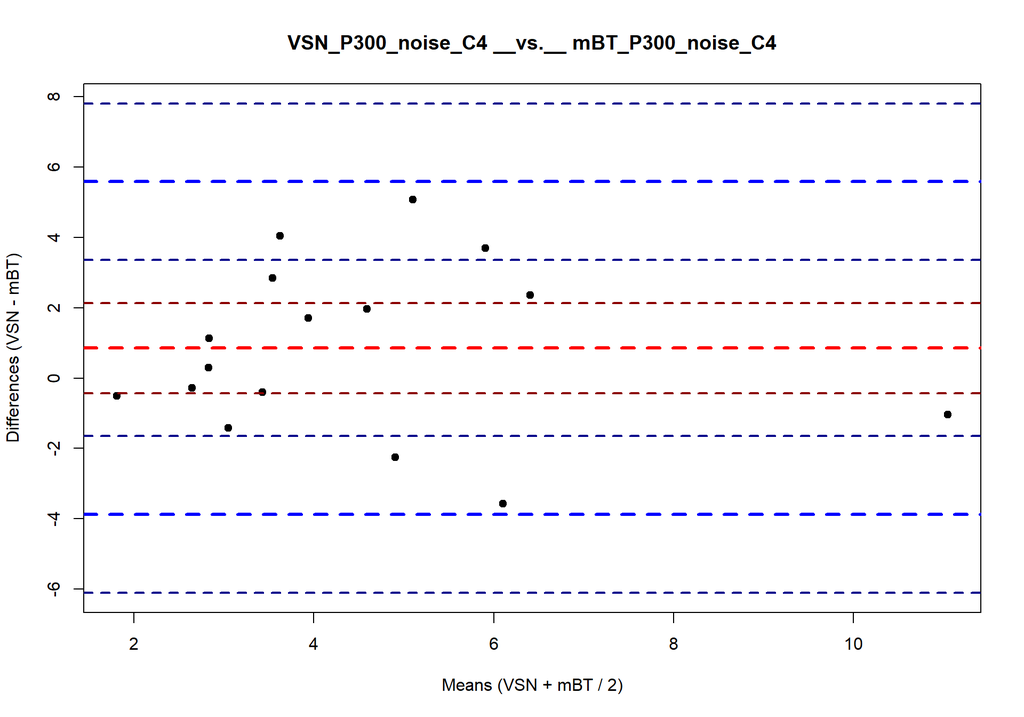

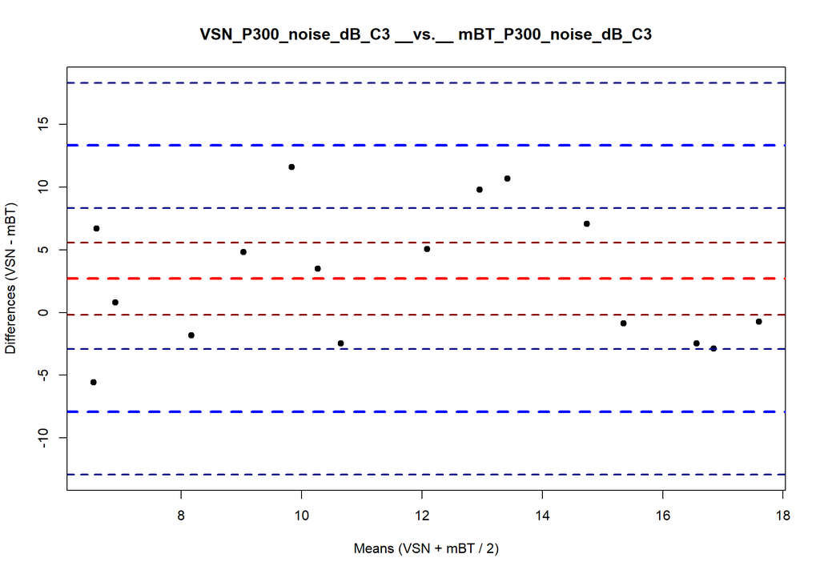

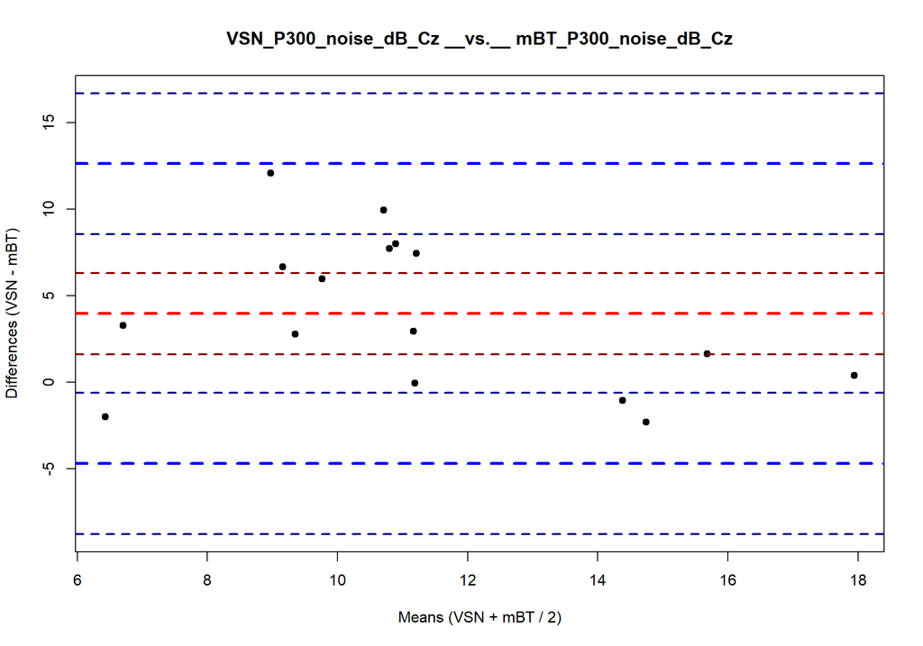

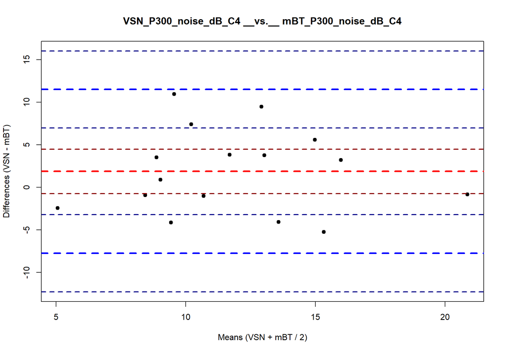

```r
##### P300 -> Csatorák külön-külön #####

for (i in 2:13){
    bland.altman.plot(as.numeric(unlist(P300[,i])), as.numeric(unlist(P300[i+12])),
                      conf.int=.95,
                      pch=19,
                      main=paste(names(P300[i]), "__vs.__",names(P300[i+12])),
                      xlab="Means (VSN + mBT / 2)",
                      ylab="Differences (VSN - mBT)")
}
```

## 3. VEP

```r
############### VEP ################
VEP <- read_excel("VEP.xlsx", sheet = 1)[,c(1:17)]
VEP_av <- read_excel("VEP.xlsx", sheet = 1)[,c(1,18:25)]
```

### VEP -> Bland-Altman plots

#### Átlagok

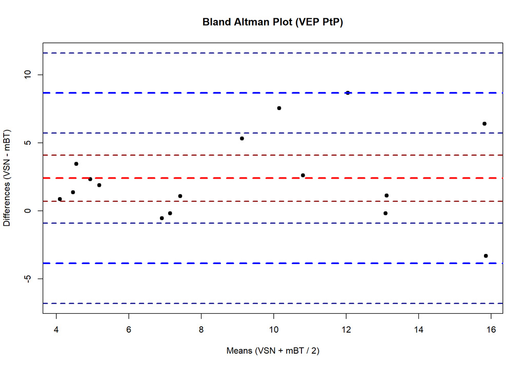

```r
############### VEP -> Bland-Altman plots ################

##### VEP -> átlagok #####

bland.altman.plot(VEP_av$VSN_VEP_PtP, VEP_av$mBT_VEP_PtP,
                  conf.int=.95,
                  pch=19,
                  main="Bland Altman Plot (VEP PtP)",
                  xlab="Means (VSN + mBT / 2)",
                  ylab="Differences (VSN - mBT)")
```

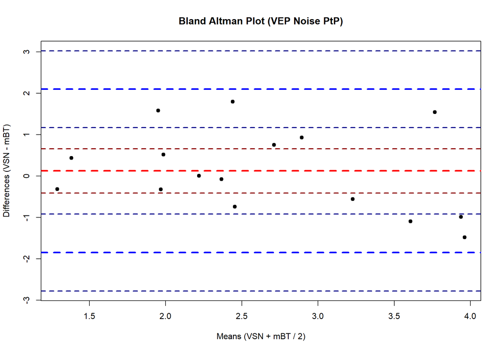

```r
bland.altman.plot(VEP_av$VSN_Noise_PtP, VEP_av$mBT_Noise_PtP,
                  conf.int=.95,
                  pch=19,
                  main="Bland Altman Plot (VEP Noise PtP)",
                  xlab="Means (VSN + mBT / 2)",
                  ylab="Differences (VSN - mBT)")
```

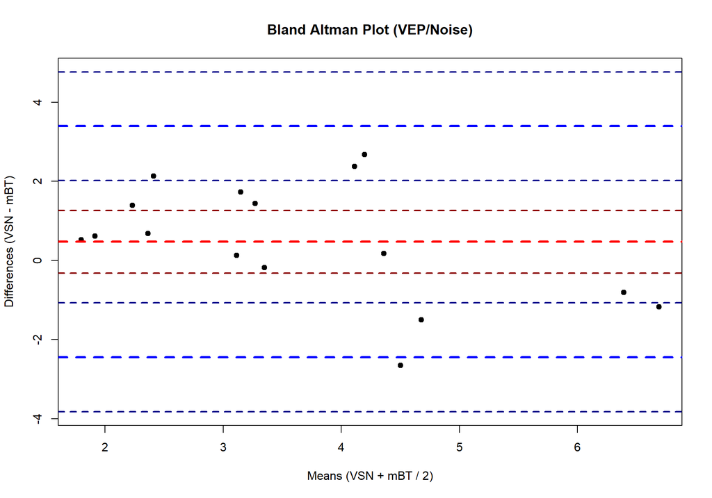

```r
bland.altman.plot(VEP_av$VSN_VEP_noise, VEP_av$mBT_VEP_noise,
                  conf.int=.95,
                  pch=19,
                  main="Bland Altman Plot (VEP/Noise)",
                  xlab="Means (VSN + mBT / 2)",
                  ylab="Differences (VSN - mBT)")
```

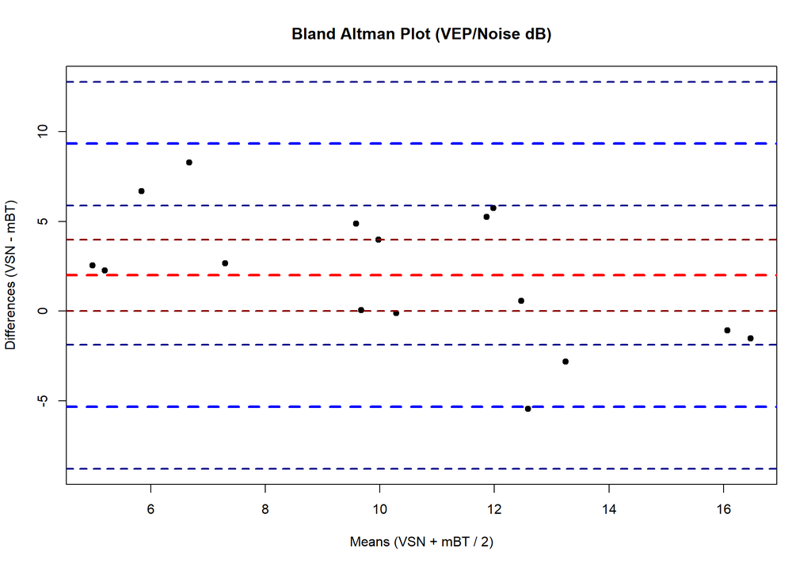

```r
bland.altman.plot(VEP_av$VSN_VEP_noise_dB, VEP_av$mBT_VEP_noise_dB,
                  conf.int=.95,
                  pch=19,
                  main="Bland Altman Plot (VEP/Noise dB)",
                  xlab="Means (VSN + mBT / 2)",
                  ylab="Differences (VSN - mBT)")
```

#### Csatorák külön-külön

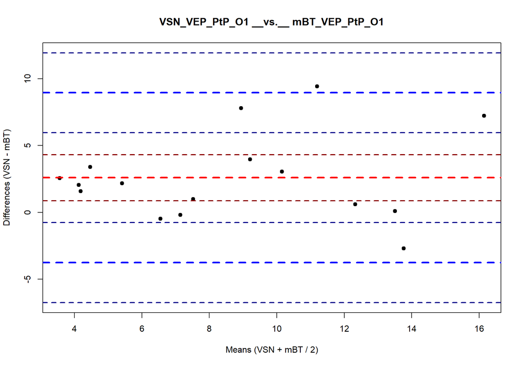

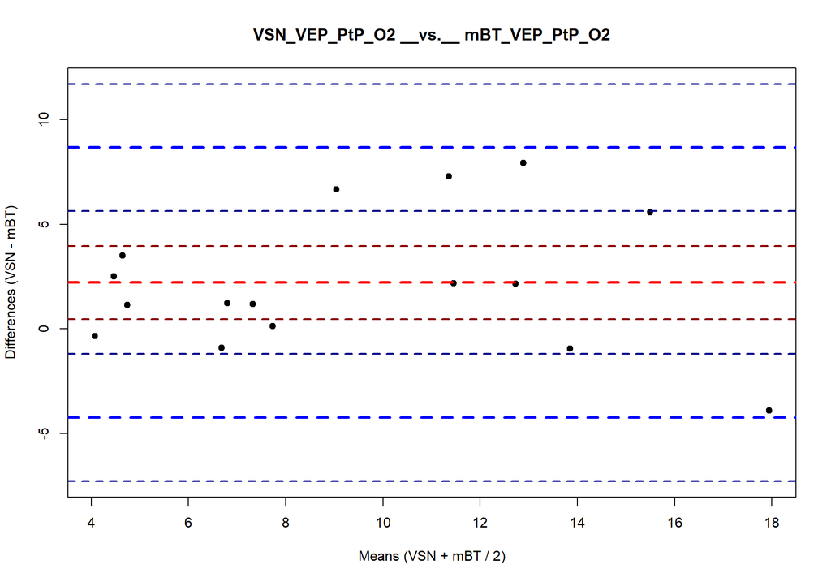

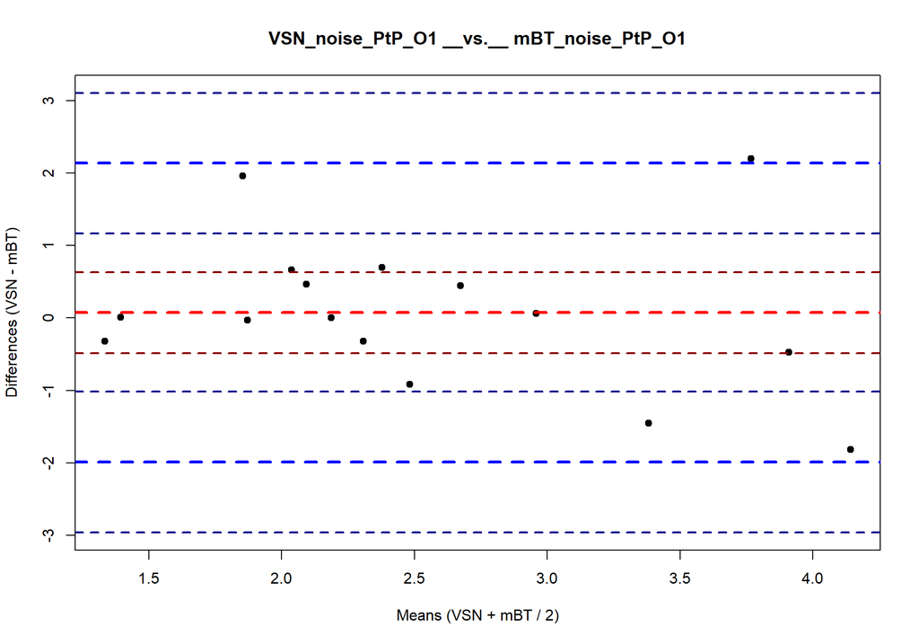

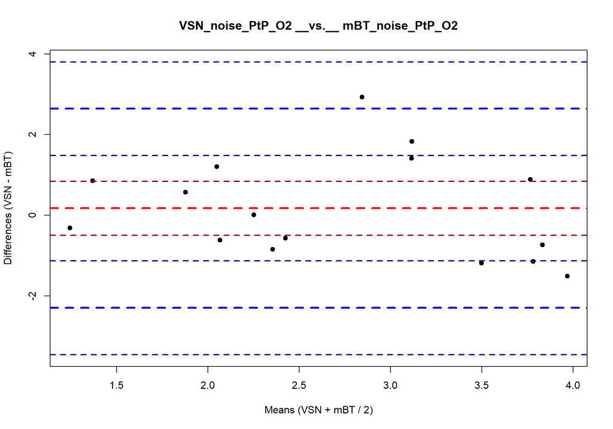

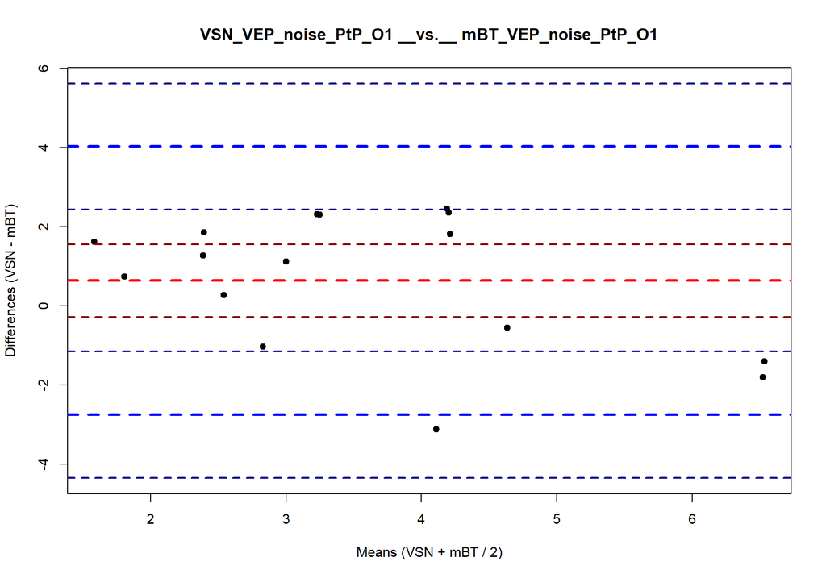

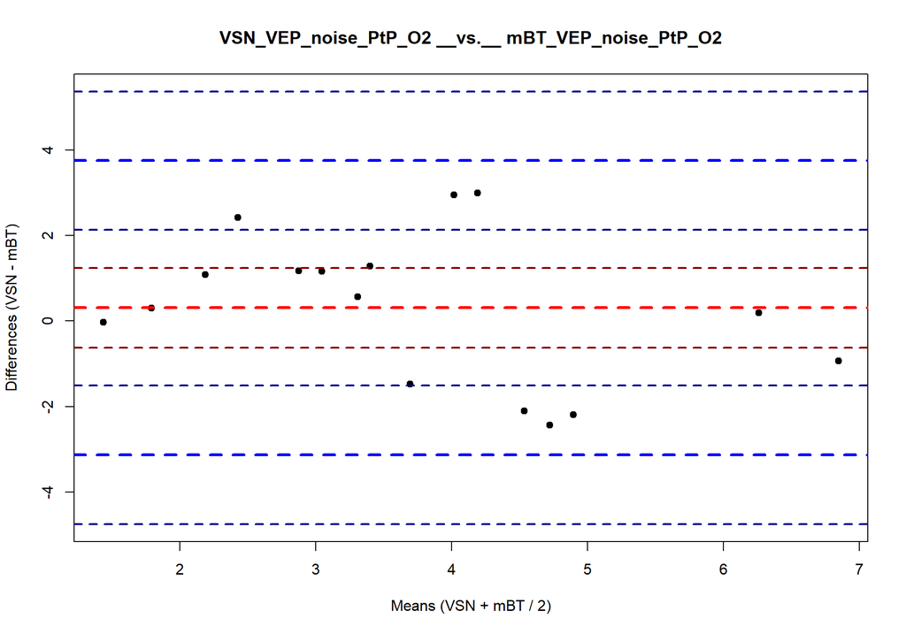

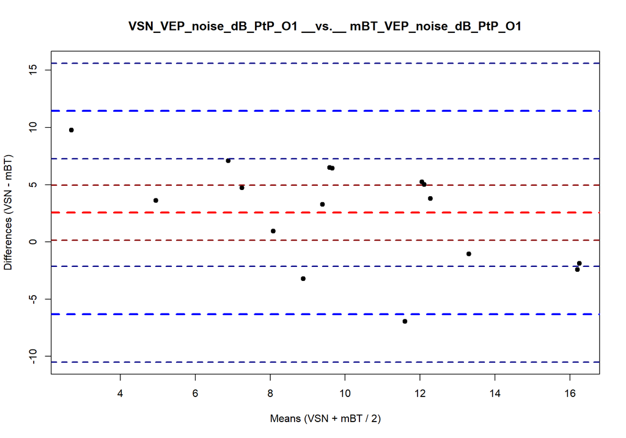

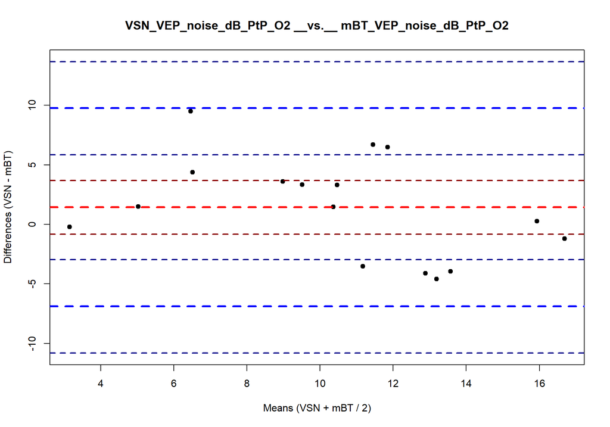

```r
##### VEP -> Csatorák külön-külön #####

for (i in 2:9){
  bland.altman.plot(as.numeric(unlist(VEP[,i])), as.numeric(unlist(VEP[i+8])),
                    conf.int=.95,
                    pch=19,
                    main=paste(names(VEP[i]), "__vs.__",names(VEP[i+8])),
                    xlab="Means (VSN + mBT / 2)",
                    ylab="Differences (VSN - mBT)")
}
```